# TMDL figures

Elise Hinman

2022-08-26

## Purpose

The purpose of this RMarkdown document is to provide a streamlined, reproducible process for generating time series and aggregated bar chart images for use in documents, presentations, and TMDLs. Currently, it is catered toward E. coli data, but it could be adapted to accommodate other data sources as well.

## Input information

The user will need to fill in the information below to run the rest of the script and generate the figures.

```r
file_path = "em_creek.csv"
au_name = "Emigration"
aggFun ="gmean" # geometric mean
correction_factor = 24465715 # correction factor for E. coli
margin_of_safety = 0.1 # percentage
rec_season=c(121,304) # days of the year
irrigation_season=c(135,288) # days of the year
site_order = data.frame(MonitoringLocationIdentifier = c(
  "BR_12.29",
  "BR_14.15",
  "BR_14.44",
  "EM_01.62",
  "EM_02.54",
  "EM_03.67",
  "EM_04.17",
  "EM_05.17",
  "EM_07.30",
  "EM_07.79",
  "EM_08.50",
  "EM_08.83",
  "EM_08.93",
  "EM_09.48",
  "EM_10.43",
  "EM_11.87",
  "KL_00.21",
  "KL_01.50"
),Order = c(1:18))
colorz = c("#f44336",
"#e81e63",
"#9c27b0",
"#673ab7",
"#3f51b5",
"#2196f3",
"#03a9f4",
"#00bcd4",
"#009688",
"#4caf50",
"#8bc34a",
"#cddc39",
"#ffeb3b",
"#ffc107",
"#ff9800",
"#ff5722",
"#795548",
"#9e9e9e",
"#607d8b",
"#000000")
# colorz = c("#034963","#0b86a3","#00a1c6","#cde3e2", "#BFD7B5","#D1CAA1","#D1D2F9","#77625C","#EFA9AE") # these are HEX color codes. Feel free to lengthen, shorten, or change the colors based on your dataset
```

## Required packages

No need to change unless fundamental figures change.

## Run tmdlCalc function

The function below aggregates data to a daily mean, determines which datapoints exceed the numeric criterion, groups data by recreation and irrigation seasons, and calculates observed and TMDL loading if flow is provided in the data. It produces an R data output that is ideal for plotting and figure production, as well as an output .csv for documentation and tracking purposes.

```r
source("R/tmdlCalcs.R")
output = tmdlCalcs(wb_path = file_path, aggFun = aggFun, cf = correction_factor, mos = margin_of_safety, rec_ssn = rec_season, irg_ssn = irrigation_season, exportfromfunc = TRUE)
head(output)
```

```
##   BeneficialUse MonitoringLocationIdentifier       Date CharacteristicName
## 1            2B                     EM_05.17 2010-04-13            E. coli
## 2            2B                     EM_07.79 2010-04-13            E. coli
## 3            2B                     EM_11.87 2010-04-15            E. coli
## 4            2B                     EM_05.17 2010-05-06            E. coli
## 5            2B                     EM_07.79 2010-05-06            E. coli
## 6            2B                     EM_11.87 2010-05-06            E. coli
##   ResultMeasure.MeasureUnitCode NumericCriterion DailyResultMeasureValue
## 1                     MPN/100mL              206                13.01438
## 2                     MPN/100mL              206                40.60970
## 3                     MPN/100mL              206                10.65535
## 4                     MPN/100mL              206                25.66515
## 5                     MPN/100mL              206                17.04985
## 6                     MPN/100mL              206                 3.19974
##   Exceeds Season Rec_Season     Irg_Season
## 1       0 Spring    not rec not irrigation
## 2       0 Spring    not rec not irrigation
## 3       0 Spring    not rec not irrigation
## 4       0 Spring        rec not irrigation
## 5       0 Spring        rec not irrigation
## 6       0 Spring        rec not irrigation
```

## Create Aggregation Table Stats

```r
gmean = function(x){exp(mean(log(x)))}
dat = output
dat_agg = output%>%group_by(MonitoringLocationIdentifier, CharacteristicName,ResultMeasure.MeasureUnitCode)%>%summarise(daterange = paste0(min(Date)," to ",max(Date)),samplesize=length(DailyResultMeasureValue),minconc = min(DailyResultMeasureValue),arithmean=mean(DailyResultMeasureValue),maxconc = max(DailyResultMeasureValue), perc_exc = sum(Exceeds)/length(Exceeds)*100)
rec_mean = output%>%filter(Rec_Season=="rec")%>%group_by(MonitoringLocationIdentifier, CharacteristicName,ResultMeasure.MeasureUnitCode)%>%summarise(rec_ssn_arithmean=mean(DailyResultMeasureValue),rec_ssn_perc_exc = sum(Exceeds)/length(Exceeds)*100)
dat_agg = merge(dat_agg, rec_mean, all = TRUE)
if(aggFun=="gmean"){
  dat_agg_geo = output%>%group_by(MonitoringLocationIdentifier, CharacteristicName, ResultMeasure.MeasureUnitCode)%>%summarise(geomean = gmean(DailyResultMeasureValue))
  rec_geo = output%>%filter(Rec_Season=="rec")%>%group_by(MonitoringLocationIdentifier, CharacteristicName, ResultMeasure.MeasureUnitCode)%>%summarise(rec_ssn_geomean=gmean(DailyResultMeasureValue))
  dat_agg_geo = merge(dat_agg_geo, rec_geo, all = TRUE)
}
dat_agg = merge(dat_agg, dat_agg_geo, all = TRUE)
if("DailyFlowValue"%in%colnames(output)){
  flo_agg = output%>%filter(!is.na(DailyFlowValue))%>%group_by(MonitoringLocationIdentifier, ResultMeasure.MeasureUnitCode)%>%summarise(daterange = paste0(min(Date)," to ",max(Date)),samplesize=length(DailyFlowValue),minconc = min(DailyFlowValue),arithmean=mean(DailyFlowValue),maxconc = max(DailyFlowValue))
  dat_agg = plyr::rbind.fill(dat_agg, flo_agg)
  dat_agg$CharacteristicName[is.na(dat_agg$CharacteristicName)] = "Flow"
}
write.csv(dat_agg, paste0(au_name,"_summary_table_stats.csv"), row.names = FALSE)
head(dat_agg)
```

```
##   MonitoringLocationIdentifier CharacteristicName ResultMeasure.MeasureUnitCode
## 1                     BR_12.29            E. coli                     MPN/100mL
## 2                     BR_14.15            E. coli                     MPN/100mL
## 3                     BR_14.44            E. coli                     MPN/100mL
## 4                     EM_01.62            E. coli                     MPN/100mL
## 5                     EM_02.54            E. coli                     MPN/100mL
## 6                     EM_03.67            E. coli                     MPN/100mL
##                  daterange samplesize minconc arithmean maxconc  perc_exc
## 1 2021-07-06 to 2021-09-09          3   204.6 281.83333   365.4 66.666667
## 2 2021-07-06 to 2021-09-09          3     7.3 286.80000   613.1 66.666667
## 3 2010-06-10 to 2022-08-08        121     0.0  60.50135  2420.0  4.132231
## 4 2011-06-08 to 2022-08-08        115     0.0 536.48762  2420.0 46.086957
## 5 2010-08-10 to 2022-08-08        120     0.0 240.60591  2420.0 30.000000
## 6 2011-06-08 to 2022-08-08        113     0.0 439.50298  2420.0 42.477876
##   rec_ssn_arithmean rec_ssn_perc_exc  geomean rec_ssn_geomean
## 1          281.8333        66.666667 274.1144        274.1144
## 2          286.8000        66.666667 102.4130        102.4130
## 3          104.4550         7.692308   0.0000          0.0000
## 4          745.8793        62.711864   0.0000          0.0000
## 5          329.0145        44.262295   0.0000          0.0000
## 6          435.5986        52.542373   0.0000          0.0000
```

## Upstream/Downstream

This code block uses the site order specified at the beginning of this document to plot all samples collected at each site and show the overall sample mean or geometric mean. The points are randomly jittered for easier viewing of the data distribution/frequency of sample values. As such, re-rendering the plot may produce slightly different looking point locations, but the values should remain the same.

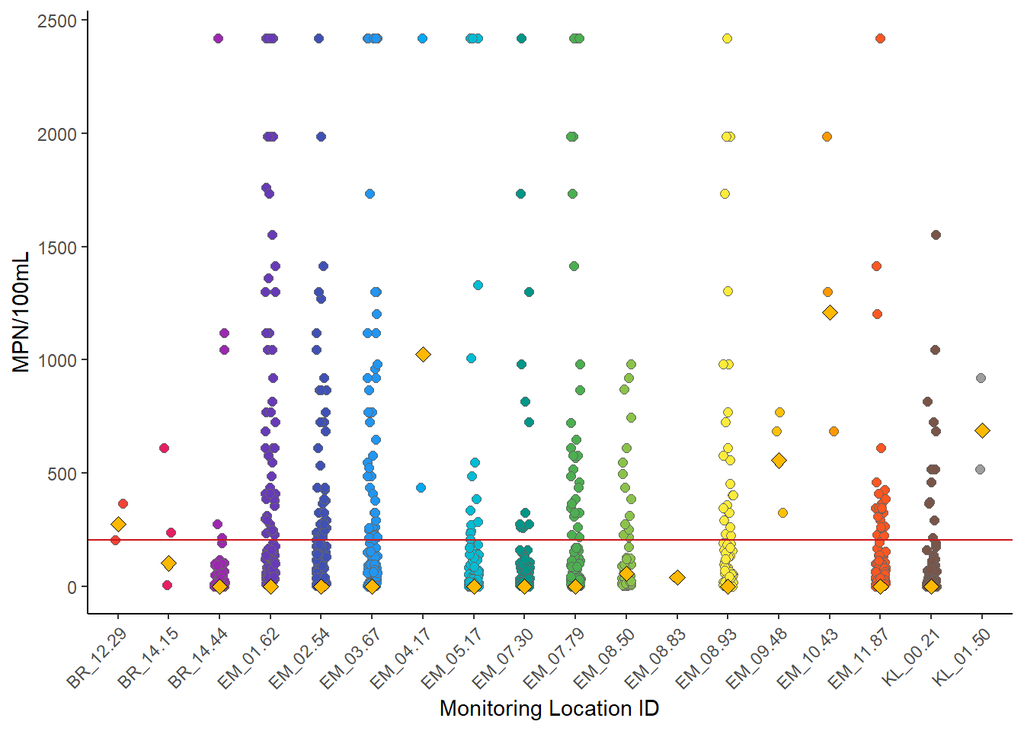

```r
## GGPLOT
sites = site_order[order(site_order$Order),]
sites = as.character(sites$MonitoringLocationIdentifier)
dat = output
dat$MonitoringLocationIdentifier = factor(as.character(dat$MonitoringLocationIdentifier), levels = sites)

f = ggplot(dat, aes(x=MonitoringLocationIdentifier,y=DailyResultMeasureValue))+geom_jitter(aes(fill=factor(MonitoringLocationIdentifier)), position=position_jitter(0.1), shape=21, size=2, color="#646464")+scale_fill_manual(values= colorsy)+theme_classic()+labs(x="Monitoring Location ID", y=unique(dat$ResultMeasure.MeasureUnitCode))+stat_summary(fun=gmean, geom="point", fill="#FFB800",color="black", size=2.5, shape=23)+geom_hline(yintercept=unique(dat$NumericCriterion), color="#cb181d",size=0.5)+theme(legend.position = "none", axis.text.x=element_text(angle=45, hjust=1)) # NOTE, should adjust numeric criterion line to accommodate variable criteria (e.g. hardness-dependent)
f
```

```r
ggsave(paste0(au_name,"_downstream_upstream.jpg"),width=6,height=4, units="in", dpi=500)
```

## Timeseries

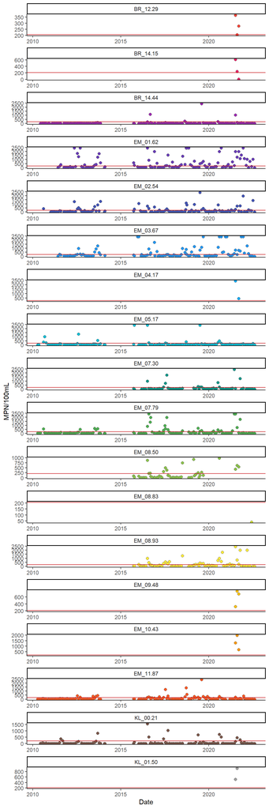

```r
dat = output
dat = dat[order(dat$Date),]
dat$MonitoringLocationIdentifier = factor(as.character(dat$MonitoringLocationIdentifier), levels = sites)

t = ggplot(dat, aes(Date,DailyResultMeasureValue, fill=as.factor(MonitoringLocationIdentifier)))+scale_x_date(limits=c(min(dat$Date), max(dat$Date)))+geom_point(shape=21,color="#646464", size=2)+facet_wrap(vars(MonitoringLocationIdentifier), scales="free", ncol=1)+theme_classic()+labs(x="Date", y=unique(dat$ResultMeasure.MeasureUnitCode))+geom_hline(yintercept=unique(dat$NumericCriterion), color="#cb181d",size=0.5)+theme(legend.position = "none")+scale_fill_manual(values=colorsy)
t
```

```r
ggsave(paste0(au_name,"_timeseries.jpg"),width=6,height=18, units="in", dpi=500)
```

## Monthly concentration plots

This code block displays all samples at each site, grouped monthly with an overall monthly mean (geometric mean). The numeric criterion is also plotted on each panel.

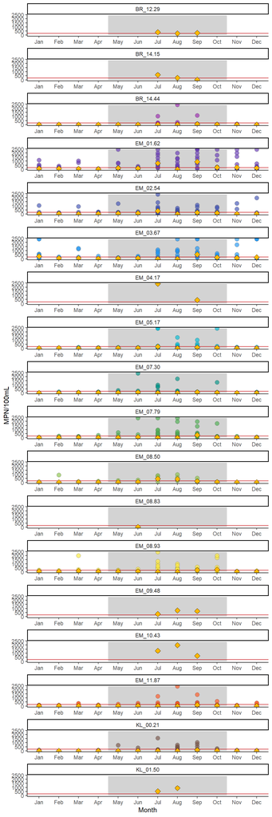

```r
dat = output
dat$month = lubridate::month(dat$Date, label=TRUE)
dat = dat[order(dat$month),]
dat$MonitoringLocationIdentifier = factor(as.character(dat$MonitoringLocationIdentifier), levels = sites)

g = ggplot(dat, aes(month, DailyResultMeasureValue, fill=factor(MonitoringLocationIdentifier)))+geom_blank()+geom_rect(aes(xmin=4.5,ymin=0,xmax=10.5,ymax=max(DailyResultMeasureValue)), fill="#D3D3D3")+scale_x_discrete(limits=month.abb)+geom_jitter(position=position_jitter(0), size=3, shape=21, color="#646464", alpha=0.65)+facet_wrap(vars(MonitoringLocationIdentifier), scales="free", ncol=1)+theme_classic()+labs(x="Month", y=unique(dat$ResultMeasure.MeasureUnitCode))+geom_hline(yintercept=unique(dat$NumericCriterion), color="#cb181d",size=0.5)+theme(legend.position = "none")+scale_fill_manual(values=colorsy)+stat_summary(fun=gmean, geom="point", fill="#FFB800",color="black", size=3, shape=23)
g
```

```r
ggsave(paste0(au_name,"_monthly.jpg"),width=6,height=18, units="in", dpi=500)
```

## Monthly Observed vs TMDL Loading

This code block uses samples for which there is a paired flow value. For each monitoring location, a bar chart is produced with side by side mean Observed Loading and TMDL values for each month for which data are present.

```r
if("TMDL"%in%colnames(output)){
  ldc=output
ldc_month = subset(ldc, !is.na(ldc$Observed_Loading))
ldc_month = ldc_month%>%select(Date,MonitoringLocationIdentifier,TMDL,Observed_Loading)%>%pivot_longer(cols=c(TMDL,Observed_Loading),names_to="Type",values_to="Loading",values_drop_na=TRUE)
ldc_month$Loading_Giga = ldc_month$Loading/1000000000
ldc_month$month = lubridate::month(ldc_month$Date, label=TRUE, abbr=TRUE)

ldc_month1 = ldc_month%>%group_by(MonitoringLocationIdentifier,Type,month)%>%summarise(mean_Load = mean(Loading_Giga))

ldcsites = unique(ldc_month1$MonitoringLocationIdentifier)
for(i in 1:length(ldcsites)){
  name = ldcsites[i]
  g = ggplot(ldc_month1, aes(x=month, y=mean_Load, fill=Type))+geom_blank()+theme_classic()+geom_rect(aes(xmin=4.5,ymin=0,xmax=10.5,ymax=max(ldc_month1$mean_Load*1.1)), fill="#D3D3D3")+scale_x_discrete(limits=month.abb)+labs(x="Month",y="GigaMPN/day")+geom_col(position="dodge", color="#646464")+scale_fill_manual(values=c("#00a1c6","#034963"),name="",breaks=c("Observed_Loading","TMDL"),labels=c("Observed","TMDL"))+guides(color="none")
  g
  ggsave(paste0(name,"_monthly_load.jpg"),width=8,height=4, units="in", dpi=500)
}
g
}
```

## Load Duration Curve

```r
if("TMDL"%in%colnames(output)){
  ldc = output
ldc$TMDL_giga = ldc$TMDL/1000000000
ldc$Observed_Loading_giga = ldc$Observed_Loading/1000000000
ldc = ldc[order(ldc$Flow_Percentile),]

exceed = subset(ldc, !is.na(ldc$Observed_Loading_giga))
exceed = within(exceed,{
  regime=NA
  regime[Flow_Percentile<10] = "High \nFlows"
  regime[Flow_Percentile>9&Flow_Percentile<40] = "Moist \nConditions"
  regime[Flow_Percentile>39&Flow_Percentile<60] = "Mid-Range \nFlows"
  regime[Flow_Percentile>59&Flow_Percentile<90] = "Dry \nConditions"
  regime[Flow_Percentile>89&Flow_Percentile<101] = "Low \nFlows"
})

exceed = exceed%>%group_by(MonitoringLocationIdentifier, regime)%>%summarise(perc_exceed=round(length(Exceeds[Exceeds==1])/length(Exceeds)*100,digits=0))

exceed = within(exceed,{
  place = NA
  place[regime=="High \nFlows"] =5
  place[regime=="Moist \nConditions"] = 25
  place[regime=="Mid-Range \nFlows"]=50
  place[regime=="Dry \nConditions"] = 75
  place[regime=="Low \nFlows"] = 95
})

exceed$label = paste0(exceed$regime,"\n(",exceed$perc_exceed,"%)")
ldcsites = unique(exceed$MonitoringLocationIdentifier)
for(i in 1:length(ldcsites)){
  name = ldcsites[i]
  why = max(c(ldc$TMDL_giga,ldc$Observed_Loading_giga), na.rm = TRUE)*0.8
  l = ggplot(ldc, aes(x=Flow_Percentile))+geom_blank()+geom_vline(xintercept=c(10,40,60,90),linetype=2)+geom_line(aes(y=TMDL_giga, color="TMDL_giga"),color="#034963",size=1.5)+geom_point(aes(y=Observed_Loading_giga, color="Observed_Loading_giga"),shape=21, color="#464646",fill="#00a1c6",size=3)+theme_classic()+labs(x="Flow Percentile",y="GigaMPN/day")+annotate("text",x=exceed$place,y=why, label=exceed$label)+scale_color_manual(name = "",
values = c( "TMDL_giga" = "#034963", "Observed_Loading_giga" = "#00a1c6"),
labels = c("TMDL", "Observed Loading"))
l
ggsave(paste0(name,"_ldc.jpg"),width=8,height=4, units="in", dpi=500)
}
l
}
```

## Flow timeseries

STILL WORKING ON THIS PART. SHOULD IT BE GAGE DATA OR DATA FROM THE SHEET?

```r
flow = subset(output, !is.na(output$DailyFlowValue))
h=ggplot(flow, aes(x=Date,y=DailyFlowValue))+geom_area(color="#646464",fill="#0b86a3")+labs(x="Date",y="Flow (cfs)")+theme_classic()
h
ggsave(paste0(au_name,"_flow_ts.jpg"),width=8,height=4, units="in", dpi=500)

flow$month = lubridate::month(flow$Date)
flo_month = flow%>%group_by(month)%>%summarise(mean_monthly = mean(DailyFlowValue, na.rm=TRUE))

m = ggplot(flo_month, aes(x=month, y=mean_monthly))+geom_col(color="#646464",fill="#0b86a3")+labs(x="Month",y="Flow (cfs)")+theme_classic()+scale_x_discrete(limits=month.abb)
m
ggsave(paste0(au_name,"_flow_monthly.jpg"),width=8,height=4, units="in", dpi=500)
```